# linear model

## Model 3 mpg~disp+hp

```r
cor(mtcars[, c("mpg", "disp", "hp")])
```

```
##             mpg       disp         hp
## mpg   1.0000000 -0.8475514 -0.7761684
## disp -0.8475514  1.0000000  0.7909486
## hp   -0.7761684  0.7909486  1.0000000
```

### Numerical results (cor)

```r
cor(mtcars[, c("mpg", "disp", "hp")])
```

```
##             mpg       disp         hp
## mpg   1.0000000 -0.8475514 -0.7761684
## disp -0.8475514  1.0000000  0.7909486
## hp   -0.7761684  0.7909486  1.0000000
```

Both displacement and horsepower have strong negative correlations with miles per gallon. However, displacement and horsepower also have a strong positive correlation with one another. This suggests that the two explanatory variables share some of the same information, which may affect their individual contributions to the multiple regression model.

### Inferential (Build 2-dimentional model.3)

```r
model.3 <- lm(mpg ~ disp + hp, data = mtcars)
summary(model.3)
```

```
##
## Call:
## lm(formula = mpg ~ disp + hp, data = mtcars)
##
## Residuals:
##     Min      1Q  Median      3Q     Max
## -4.7945 -2.3036 -0.8246  1.8582  6.9363
##
## Coefficients:
##              Estimate Std. Error t value Pr(>|t|)
## (Intercept) 30.735904   1.331566  23.083  < 2e-16 ***
## disp        -0.030346   0.007405  -4.098 0.000306 ***
## hp          -0.024840   0.013385  -1.856 0.073679 .
## ---
## Signif. codes:  0 '***' 0.001 '**' 0.01 '*' 0.05 '.' 0.1 ' ' 1
##
## Residual standard error: 3.127 on 29 degrees of freedom
## Multiple R-squared:  0.7482, Adjusted R-squared:  0.7309
## F-statistic: 43.09 on 2 and 29 DF,  p-value: 2.062e-09
```

Model 3 uses both displacement and horsepower to predict miles per gallon. Together, these variables explain approximately 74.8% of the variation in fuel efficiency.

Although the overall regression model is statistically significant, horsepower is not individually significant at the 0.05 significance level after controlling for displacement. This may be explained in part by the strong correlation between displacement and horsepower.

#### predict model.3 at target point

```r
newdata.3 <- data.frame(
  disp = 183,
  hp = 250
)

predict(model.3,
        newdata = newdata.3,
        interval = "prediction",
        level = 0.95)
```

```
##        fit     lwr      upr
## 1 18.97252 11.6292 26.31583
```

For a vehicle with an engine displacement of 183 cubic inches and 250 horsepower, Model 3 predicts a fuel efficiency of approximately 18.97 miles per gallon. The 95% prediction interval ranges from 11.63 to 26.32 miles per gallon.

This model considers both explanatory variables when predicting fuel efficiency.

## Comparing nested models ANOVA Test

### Model.1 vs Model.3

```r
anova(model.1, model.3)
```

```
## Analysis of Variance Table
##
## Model 1: mpg ~ disp
## Model 2: mpg ~ disp + hp
##   Res.Df    RSS Df Sum of Sq      F  Pr(>F)
## 1     30 317.16
## 2     29 283.49  1    33.665 3.4438 0.07368 .
## ---
## Signif. codes:  0 '***' 0.001 '**' 0.01 '*' 0.05 '.' 0.1 ' ' 1
```

An ANOVA test was conducted to determine whether adding horsepower to the regression model containing displacement significantly improves the model.

The residual sum of squares decreased from 317.16 in Model 1 to 283.49 in Model 3. The ANOVA test produced an F-statistic of 3.4438 and a p-value of 0.07368.

Since the p-value is greater than the significance level of 0.05, we fail to reject the null hypothesis. There is insufficient statistical evidence to conclude that adding horsepower to the displacement model significantly improves its predictive ability. Therefore, Model 1 may be preferred because it is simpler and explains a similar percentage of the variation in miles per gallon.

### Model.2 vs Model.3

```r
anova(model.2, model.3)
```

```
## Analysis of Variance Table
##
## Model 1: mpg ~ hp
## Model 2: mpg ~ disp + hp
##   Res.Df    RSS Df Sum of Sq      F    Pr(>F)
## 1     30 447.67
## 2     29 283.49  1    164.18 16.795 0.0003063 ***
## ---
## Signif. codes:  0 '***' 0.001 '**' 0.01 '*' 0.05 '.' 0.1 ' ' 1
```

```r
comparison <- data.frame(
  Model = c("Model 1", "Model 2", "Model 3"),
  R_squared = c(
    summary(model.1)$r.squared,
    summary(model.2)$r.squared,
    summary(model.3)$r.squared
  ),
  Adjusted_R_squared = c(
    summary(model.1)$adj.r.squared,
    summary(model.2)$adj.r.squared,
    summary(model.3)$adj.r.squared
  ),
  Residual_SE = c(
    summary(model.1)$sigma,
    summary(model.2)$sigma,
    summary(model.3)$sigma
  )
)

knitr::kable(comparison, digits = 4)
```

| Model | R_squared | Adjusted_R_squared | Residual_SE |
| --- | --- | --- | --- |
| Model 1 | 0.7183 | 0.7090 | 3.2515 |
| Model 2 | 0.6024 | 0.5892 | 3.8630 |
| Model 3 | 0.7482 | 0.7309 | 3.1266 |

The purpose of this ANOVA test is to determine whether adding displacement to Model 2 significantly improves the regression model.

**Null Hypothesis:** Adding displacement to the horsepower model does not significantly improve the model.

**Alternative Hypothesis:** Adding displacement to the horsepower model significantly improves the model.

The ANOVA test produced an F-statistic of 16.795 and a p-value of 0.0003063. The residual sum of squares decreased from 447.67 to 283.49. Since the p-value is less than the significance level of 0.05, we reject the null hypothesis. There is sufficient statistical evidence to conclude that adding displacement to the horsepower model significantly improves the model.

## How do the models compare (Model.1 with model.2 in the anova results)?

When comparing the three regression models, Model 1 explains approximately 71.83% of the variation in miles per gallon, Model 2 explains approximately 60.24%, and Model 3 explains approximately 74.82%.

The ANOVA results show that adding horsepower to the displacement model does not significantly improve the model. However, adding displacement to the horsepower model does significantly improve the model.

These results suggest that displacement is a stronger predictor of miles per gallon than horsepower in this dataset. Although Model 3 explains the greatest percentage of variation, Model 1 may be preferred because it provides a relatively strong prediction using only one explanatory variable.

Model 1 and Model 2 cannot be directly compared using a nested-model ANOVA test because neither model contains all the explanatory variables of the other. However, their R-squared values and residual standard errors indicate that Model 1 provides a better fit to the data than Model 2.

## Discussion and Conclusion

## Additional Linear Regression Analysis

The following analysis examines the relationship between vehicle weight, engine displacement, and fuel efficiency. Three additional regression models will be used to predict miles per gallon for a vehicle weighing 3,050 pounds with an engine displacement of 122 cubic inches.

### Weight and MPG

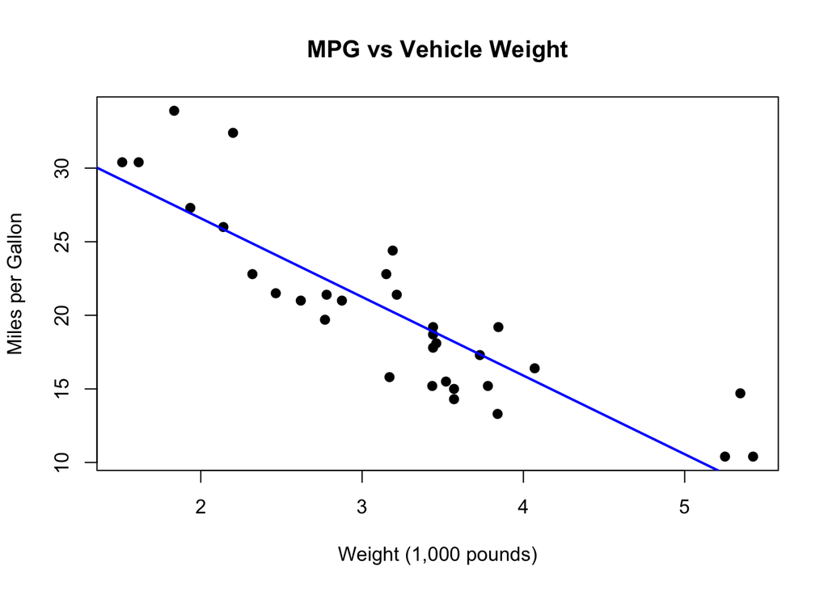

```r
weight.model <- lm(mpg ~ wt, data = mtcars)

plot(mpg ~ wt, data = mtcars,
     pch = 19,
     main = "MPG vs Vehicle Weight",
     xlab = "Weight (1,000 pounds)",
     ylab = "Miles per Gallon")

abline(weight.model, col = "blue", lwd = 2)
```

```r
cor(mtcars$mpg, mtcars$wt)
```

```
## [1] -0.8676594
```

```r
summary(weight.model)
```

```
##
## Call:
## lm(formula = mpg ~ wt, data = mtcars)
##
## Residuals:
##     Min      1Q  Median      3Q     Max
## -4.5432 -2.3647 -0.1252  1.4096  6.8727
##
## Coefficients:
##             Estimate Std. Error t value Pr(>|t|)
## (Intercept)  37.2851     1.8776  19.858  < 2e-16 ***
## wt           -5.3445     0.5591  -9.559 1.29e-10 ***
## ---
## Signif. codes:  0 '***' 0.001 '**' 0.01 '*' 0.05 '.' 0.1 ' ' 1
##
## Residual standard error: 3.046 on 30 degrees of freedom
## Multiple R-squared:  0.7528, Adjusted R-squared:  0.7446
## F-statistic: 91.38 on 1 and 30 DF,  p-value: 1.294e-10
```

```r
predict(weight.model,
        data.frame(wt = 3.050),
        interval = "prediction",
        level = 0.95)
```

```
##        fit      lwr      upr
## 1 20.98449 14.66463 27.30434
```

The scatterplot shows a negative linear relationship between vehicle weight and miles per gallon. The correlation coefficient is approximately -0.868, indicating a strong negative relationship. As vehicle weight increases, fuel efficiency generally decreases.

The regression model explains approximately 75.28% of the variation in miles per gallon. The p-value of 1.294e-10 indicates that weight is a statistically significant predictor of fuel efficiency.

For a vehicle weighing 3,050 pounds, the model predicts a fuel efficiency of approximately 20.98 miles per gallon, with a 95% prediction interval ranging from 14.66 to 27.30 miles per gallon.

### Displacement and MPG at 122 Cubic Inches

```r
predict(model.1,
        data.frame(disp = 122),
        interval = "prediction",
        level = 0.95)
```

```
##        fit      lwr     upr
## 1 24.57161 17.74762 31.3956
```

As previously demonstrated, displacement has a strong negative correlation with miles per gallon, with a correlation coefficient of approximately -0.848. The displacement model explains approximately 71.83% of the variation in fuel efficiency.

For a vehicle with an engine displacement of 122 cubic inches, the model predicts a fuel efficiency of approximately 24.57 miles per gallon. The 95% prediction interval ranges from 17.75 to 31.40 miles per gallon.

### Weight and Displacement Combined

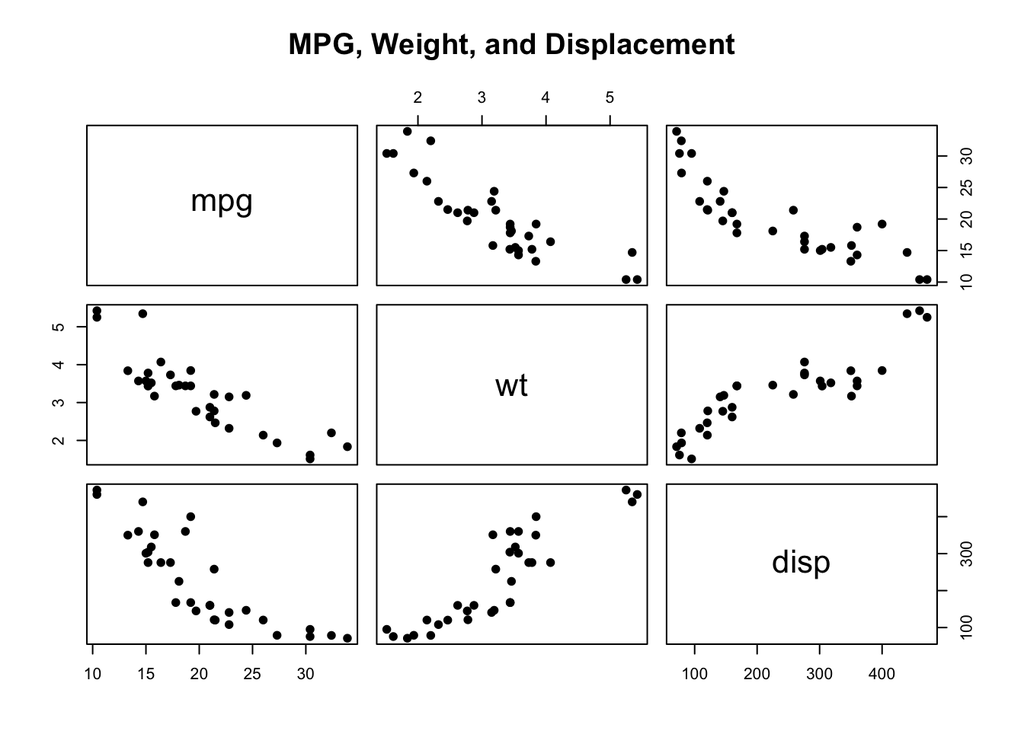

```r
pairs(mtcars[, c("mpg", "wt", "disp")],
      main = "MPG, Weight, and Displacement",
      pch = 19)
```

```r
cor(mtcars[, c("mpg", "wt", "disp")])
```

```
##             mpg         wt       disp
## mpg   1.0000000 -0.8676594 -0.8475514
## wt   -0.8676594  1.0000000  0.8879799
## disp -0.8475514  0.8879799  1.0000000
```

```r
combined.model <- lm(mpg ~ wt + disp,
                     data = mtcars)

summary(combined.model)
```

```
##
## Call:
## lm(formula = mpg ~ wt + disp, data = mtcars)
##
## Residuals:
##     Min      1Q  Median      3Q     Max
## -3.4087 -2.3243 -0.7683  1.7721  6.3484
##
## Coefficients:
##             Estimate Std. Error t value Pr(>|t|)
## (Intercept) 34.96055    2.16454  16.151 4.91e-16 ***
## wt          -3.35082    1.16413  -2.878  0.00743 **
## disp        -0.01773    0.00919  -1.929  0.06362 .
## ---
## Signif. codes:  0 '***' 0.001 '**' 0.01 '*' 0.05 '.' 0.1 ' ' 1
##
## Residual standard error: 2.917 on 29 degrees of freedom
## Multiple R-squared:  0.7809, Adjusted R-squared:  0.7658
## F-statistic: 51.69 on 2 and 29 DF,  p-value: 2.744e-10
```

```r
predict(combined.model,
        data.frame(wt = 3.050, disp = 122),
        interval = "prediction",
        level = 0.95)
```

```
##        fit      lwr      upr
## 1 22.57812 16.28661 28.86963
```

The correlation matrix shows that both vehicle weight and engine displacement have strong negative relationships with miles per gallon. Weight and displacement also have a strong positive correlation of approximately 0.888, indicating that heavier vehicles generally have larger engines.

The combined regression model explains approximately 78.09% of the variation in miles per gallon. Although the overall model is statistically significant, weight is individually significant with a p-value of 0.00743, while displacement is not individually significant after controlling for weight, with a p-value of 0.06362.

For a vehicle weighing 3,050 pounds and having an engine displacement of 122 cubic inches, the combined model predicts a fuel efficiency of approximately 22.58 miles per gallon. The 95% prediction interval ranges from 16.29 to 28.87 miles per gallon.

### Comparing Additional Models

```r
anova(weight.model, combined.model)
```

```
## Analysis of Variance Table
##
## Model 1: mpg ~ wt
## Model 2: mpg ~ wt + disp
##   Res.Df    RSS Df Sum of Sq      F  Pr(>F)
## 1     30 278.32
## 2     29 246.68  1    31.639 3.7195 0.06362 .
## ---
## Signif. codes:  0 '***' 0.001 '**' 0.01 '*' 0.05 '.' 0.1 ' ' 1
```

```r
anova(model.1, combined.model)
```

```
## Analysis of Variance Table
##
## Model 1: mpg ~ disp
## Model 2: mpg ~ wt + disp
##   Res.Df    RSS Df Sum of Sq      F   Pr(>F)
## 1     30 317.16
## 2     29 246.68  1    70.476 8.2852 0.007431 **
## ---
## Signif. codes:  0 '***' 0.001 '**' 0.01 '*' 0.05 '.' 0.1 ' ' 1
```

**Null Hypothesis:** Adding displacement to the weight model does not significantly improve the regression model.

**Alternative Hypothesis:** Adding displacement to the weight model significantly improves the regression model.

The ANOVA test produced an F-statistic of 3.7195 and a p-value of 0.06362. Since the p-value is greater than the significance level of 0.05, we fail to reject the null hypothesis. There is insufficient statistical evidence to conclude that adding displacement significantly improves the regression model containing weight.

**Null Hypothesis:** Adding weight to the displacement model does not significantly improve the regression model.

**Alternative Hypothesis:** Adding weight to the displacement model significantly improves the regression model.

The ANOVA test produced an F-statistic of 8.2852 and a p-value of 0.007431. Since the p-value is less than the significance level of 0.05, we reject the null hypothesis. There is sufficient statistical evidence to conclude that adding weight to the displacement model significantly improves the regression model.

## Discussion and Conclusion

The purpose of this project was to examine the relationship between engine displacement, horsepower, vehicle weight, and miles per gallon using linear regression models. The results showed that all three explanatory variables have strong negative relationships with fuel efficiency.

In the first analysis, displacement was found to be a stronger individual predictor of miles per gallon than horsepower. The ANOVA results showed that adding horsepower to the displacement model did not significantly improve the model. However, adding displacement to the horsepower model resulted in a statistically significant improvement.

In the additional analysis, vehicle weight was found to be a stronger individual predictor of miles per gallon than displacement. The weight model explained approximately 75.28% of the variation in fuel efficiency, while the combined weight and displacement model explained approximately 78.09%. Although the combined model explained more variation, adding displacement to the weight model did not produce a statistically significant improvement.

For a vehicle weighing 3,050 pounds with an engine displacement of 122 cubic inches, the combined model predicted a fuel efficiency of approximately 22.58 miles per gallon, with a 95% prediction interval ranging from 16.29 to 28.87 miles per gallon.

When comparing the individual explanatory variables, weight explained the greatest percentage of variation in miles per gallon, followed by displacement and horsepower. These results demonstrate that including additional explanatory variables does not always significantly improve a regression model. In some cases, a simpler model may be preferred.

One limitation of this study is that the dataset contains only 32 vehicles from the 1970s. Therefore, these results may not accurately represent modern automobiles. Other factors, such as transmission type, number of cylinders, and advances in engine technology, may also influence fuel efficiency.

Overall, this project demonstrates how linear regression models can be used to identify relationships between variables, make predictions, and determine whether additional explanatory variables significantly improve a model.